# Week 11, Day 2

# Load Libraries / Read In Data

```r
library(rpart)
library(rpart.plot)
library(tidyverse)
library(GGally)
library(janitor)
library(modelr)
library(yardstick)
library(ranger)

titanic_set <- read_csv('data/titanic_decision_tree_data.csv')

shuffle_index <- sample(1:nrow(titanic_set))

# shuffle the data so class order isn't in order - need this for training/testing split later on
titanic_set <- titanic_set[shuffle_index, ]
```

# MVP

## Q1.

```r
titanic_clean <- titanic_set %>%
  filter(survived %in% c(0,1)) %>%
# Convert to factor level
    mutate(sex = as.factor(sex),
           age_status = as.factor(if_else(age <= 16, "child", "adult")),
         class = factor(pclass, levels = c(3,2,1), labels = c("Lower", "Middle", "Upper")),
           survived_flag = factor(survived, levels = c(0,1), labels = c("No", "Yes")),
           port_embarkation = as.factor(embarked)) %>%
  select(sex, age_status, class, port_embarkation, sib_sp, parch, survived_flag) %>%
  na.omit()
```

## Q2.

From the `ggpairs()` plots below, good candidates for predictors of `survived_flag` look to be:

- `sex`
- `class`

And to a lesser extent `age_status` and `parch`.

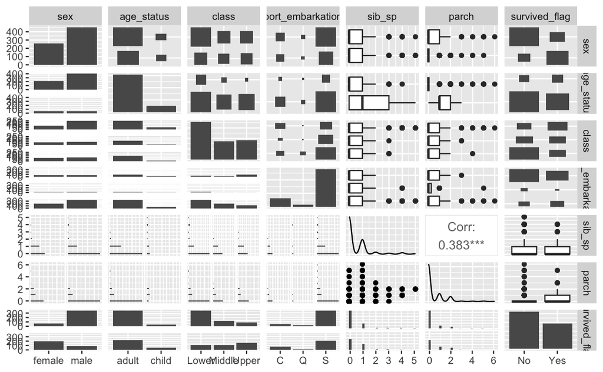

```r
ggpairs(titanic_clean,
        progress = FALSE)
```

## Q3.

Create testing and training sets. From initial research online, splitting 80% of the data for use in training and 20% in training appears to be a standard starting point and this is what I will use.

```r
n_data <- nrow(titanic_clean)

test_index <- sample(1:n_data, size = n_data * 0.2)

titanic_test <- slice(titanic_clean, test_index)
titanic_train <- slice(titanic_clean, -test_index)
```

Based on the below output tables, I am satisfied that the testing and training data is balanced.

```r
titanic_test %>%
  tabyl(survived_flag)
```

```
 survived_flag  n   percent
            No 82 0.5774648
           Yes 60 0.4225352
```

```r
titanic_train %>%
  tabyl(survived_flag)
```

```
 survived_flag   n percent
            No 342     0.6
           Yes 228     0.4
```

## Q4.

Create decision tree.

```r
titanic_fit <- rpart(
  formula = survived_flag ~ .,
  data = titanic_train,
  method = "class"
)
```

Plot decision tree.

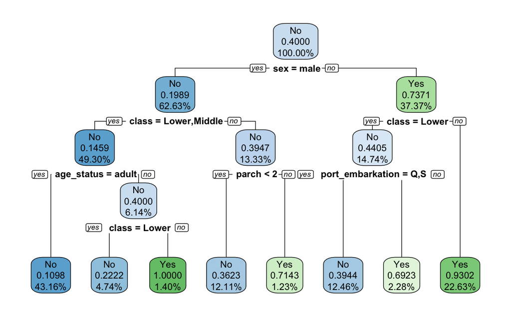

```r
rpart.plot(titanic_fit,
           yesno = 2, # Sets Yes/No Labels
           fallen.leaves = TRUE, # Align all end results at bottom.
           faclen = 6, # Number of levels that are shown for each factor
           digits = 4) # Number of decimal places
```

## Q5.

- What variables are important? The first two variables the model has used to separate are `sex` and `class` suggesting that these are the most important for categorising individual observations. This is in-line with our predictions from question 2. According to the model, `age_status`, `parch` and `port_embarkation` are also important variables.
- What does each node tell you? Depending on the arguments passed to `rpart.plot()` different information can be displayed in each note. In the above plot, each node shows 3 pieces of information.
1. The predicted class. Either yes or no, yes indicating survived, no indicating died.
2. The probability of survival (eg. we can see that according to the model 40% of overall passengers survived.
3. The percentage of observations at that stage based on previous classifications.

Who has the highest chance of surviving? Non-lower class children, followed by non-lower class women.

Who has the lowest chance of surviving? Lower or middle class adult males.

## Q6.

Add predictions

```r
titanic_test_predictions <- titanic_test %>%
  add_predictions(titanic_fit,
                  type = "class")
```

Create confusion matrix.

```r
conf_matrix <- titanic_test_predictions %>%
  conf_mat(truth = survived_flag,
           estimate = pred)

conf_matrix
```

```
          Truth
Prediction No Yes
       No  77  29
       Yes  5  31
```

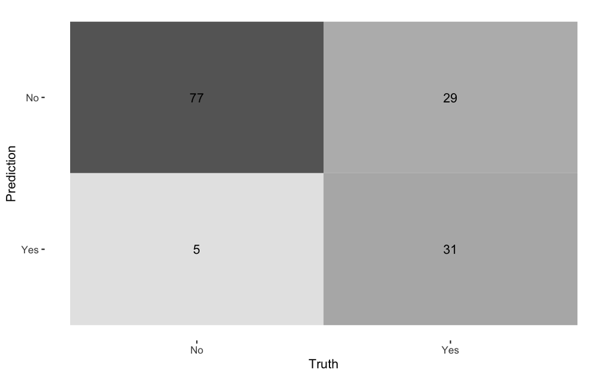

```r
autoplot(conf_matrix,
         type="heatmap")
```

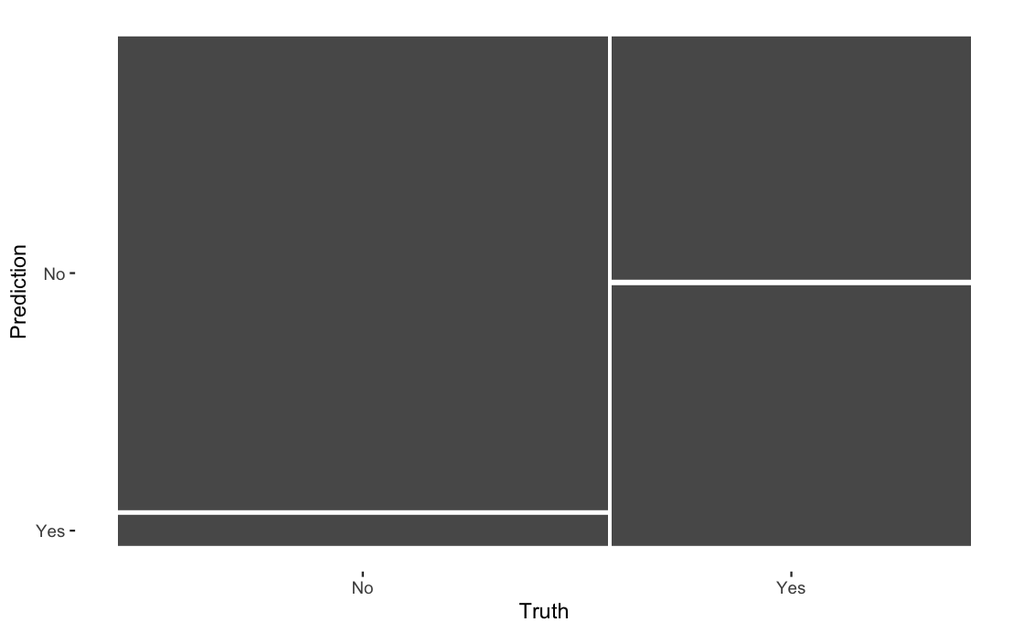

```r
autoplot(conf_matrix)
```

```r
accuracy <- titanic_test_predictions %>%
  accuracy(truth = survived_flag,
           estimate = pred)

accuracy
```

| .metric | .estimator | .estimate |
| --- | --- | --- |
| accuracy | binary | 0.7605634 |

**Interpretation**

77 predicted dead actually died. (True Negative) 5 predicted survived actually died. (False Positive)

31 predicted survived actually survived. (True Positive) 29 predicted dead actually survived. (False Negative)

Current Accuracy: 76%.

- When applied to the test data, the model classified more observations correctly (True Negative + True Positive) than it did incorrectly (False Negative + False Positive).
- However, the model has a high amount of false negatives, and predicted that 29 people who survived in real life had died.
- In contrast, only a small number of false positives were returned.
- Incorrectly predicting that a large number of people who survived had died may suggest that the observations randomly selected to be included in the training data had stronger correlations between certain variables and `survival_flag` = NO than the test data. This could be further assessed by obtaining a larger sample OR by utilising random forest methods.

# Extension

```r
control <- trainControl(
  method = "repeatedcv",
  number = 5,
  repeats = 10
)

tune_grid = expand.grid(
  mtry = 1:6,
  splitrule = c("gini", "extratrees"),
  min.node.size = c(1, 3, 5)
)
```

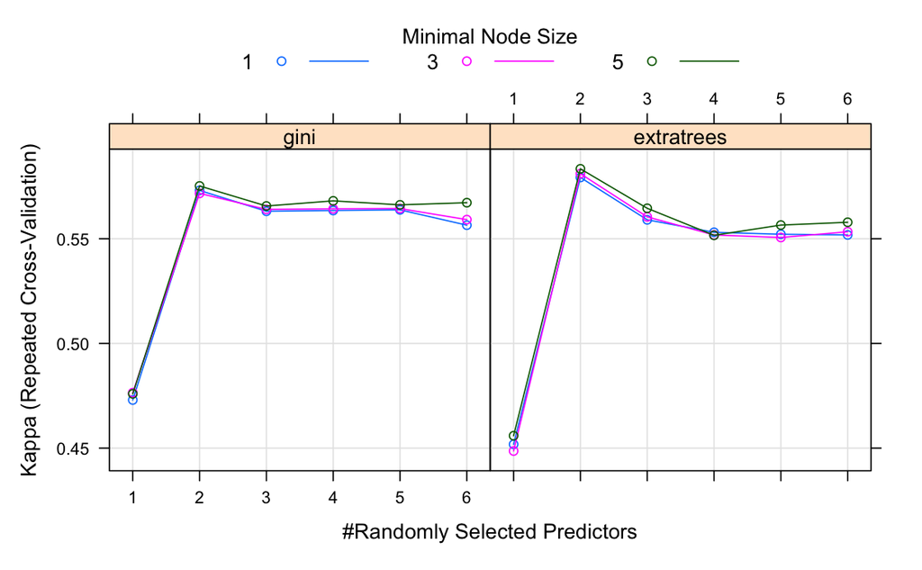

```r
rf_tune <- train(
  survived_flag ~ .,
  data = titanic_train,
  method = "ranger",
  metric = "Kappa",
  num.trees = 1000,
  importance = "impurity",
  tuneGrid = tune_grid,
  trControl = control
)

plot(rf_tune)
```

```r
rf_tune
```

```
Random Forest

570 samples
  6 predictor
  2 classes: 'No', 'Yes'

No pre-processing
Resampling: Cross-Validated (5 fold, repeated 10 times)
Summary of sample sizes: 456, 455, 457, 456, 456, 456, ...
Resampling results across tuning parameters:

  mtry  splitrule   min.node.size  Accuracy   Kappa
  1     gini        1              0.7666359  0.4729797
  1     gini        3              0.7682226  0.4764674
  1     gini        5              0.7680442  0.4759147
```

[output cut: 36 more lines]